# Assignment #3

```r
library(tidyverse)         # for graphing and data cleaning
library(tidymodels)        # for modeling
library(themis)            # for step functions for unbalanced data
library(doParallel)        # for parallel processing
library(stacks)            # for stacking models
library(naniar)            # for examining missing values (NAs)
library(lubridate)         # for date manipulation
library(moderndive)        # for King County housing data
library(vip)               # for variable importance plots
library(patchwork)         # for combining plots nicely
theme_set(theme_minimal()) # Lisa's favorite theme
```

```r
data("lending_club")
# Data dictionary (as close as I could find): https://www.kaggle.com/wordsforthewise/lending-club/discussion/170691
```

When you finish the assignment, remove the `#` from the options chunk at the top, so that messages and warnings aren’t printed. If you are getting errors in your code, add `error = TRUE` so that the file knits. I would recommend not removing the `#` until you are completely finished.

## Put it on GitHub!

From now on, GitHub should be part of your routine when doing assignments. I recommend making it part of your process anytime you are working in R, but I’ll make you show it’s part of your process for assignments.

**Task**: When you are finished with the assignment, post a link below to the GitHub repo for the assignment. Make sure the link goes to a spot in the repo where I can easily find this assignment. For example, if you have a website with a blog and post the assignment as a blog post, link to the post’s folder in the repo. As an example, I’ve linked to my GitHub stacking material [here](https://github.com/llendway/ads_website/tree/master/_posts/2021-03-22-stacking).

[github link](https://github.com/RitaLiu6/Stats456_assignment3)

## Modeling

We’ll be using the `lending_club` dataset from the `modeldata` library, which is part of `tidymodels`. The data dictionary they reference doesn’t seem to exist anymore, but it seems the one on this [kaggle discussion](https://www.kaggle.com/wordsforthewise/lending-club/discussion/170691) is pretty close. It might also help to read a bit about [Lending Club](https://en.wikipedia.org/wiki/LendingClub) before starting in on the exercises.

The outcome we are interested in predicting is `Class`. And according to the dataset’s help page, its values are “either ‘good’ (meaning that the loan was fully paid back or currently on-time) or ‘bad’ (charged off, defaulted, or 21-120 days late)”.

**Tasks:**

1. Explore the data, concentrating on examining distributions of variables and examining missing values.

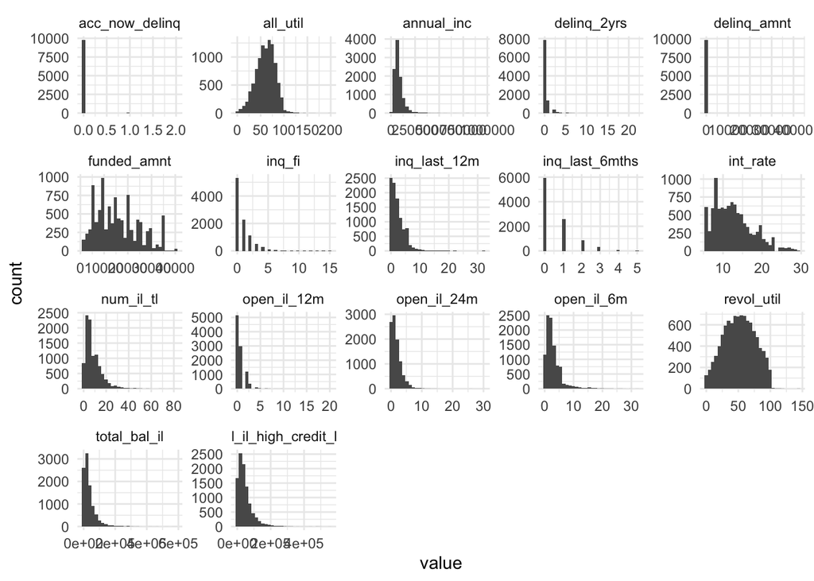

```r
lending_club %>%
  select(where(is.numeric)) %>%
  pivot_longer(cols = everything(),
               names_to = "variable",
               values_to = "value") %>%
  ggplot(aes(x = value)) +
  geom_histogram(bins = 30) +
  facet_wrap(vars(variable),
             scales = "free")
```

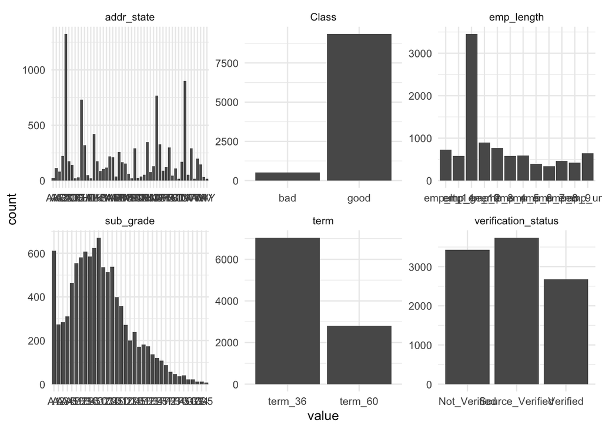

```r
lending_club %>%
  select(where(is.factor)) %>%
  pivot_longer(cols = everything(),
               names_to = "variable",
               values_to = "value") %>%
  ggplot(aes(x = value)) +
  geom_bar() +
  facet_wrap(vars(variable),
             scales = "free",
             nrow = 2)
```

```r
lending_club %>%
  add_n_miss() %>%
  count(n_miss_all)
```

| n_miss_all | n |
| --- | --- |
| 0 | 9857 |

> I think many of the numeric variables are right-skewed. Also, the number of the bad and the good class are very imbalanced. However, the data is very compelete and there is no missing data.
2. Split the data into training and test, putting 75% in the training data. Stratify by `Class` (add `strata =`Class`to the`initial_split()` function).

```r
set.seed(494) # for reproducibility

# remove the #'s once you've defined these - this is so we all have the same name
lending_split <- initial_split(lending_club,
                             prop = .75,
                             strata = Class)

lending_training <- training(lending_split)
lending_test <- testing(lending_split)
```

3. Set up the recipe and the pre-processing steps to build a lasso model. Some steps you should take:
- Use `step_upsample()` from the `themis` library to upsample the “bad” category so that it is 50% of the “good” category. Do this by setting `over_ratio = .5`.
- Use `step_downsample()` from the `themis` library to downsample the “good” category so the bads and goods are even - set `under_ratio = 1`. Make sure to do this step AFTER `step_upsample()`.
- Make all integer variables numeric (I’d highly recommend using `step_mutate_at()` and using the `all_numeric()` helper or this will be a lot of code). This step might seem really weird right now, but we’ll want to do this for the model interpretation we’ll do in a later assignment.
- Think about grouping factor variables with many levels.
- Make categorical variables dummy variables (make sure NOT to do this to the outcome variable).
- Normalize quantitative variables.

Once you have that, use `prep()`, `juice()`, and `count()` to count the number of observations in each class. They should be equal. This dataset will be used in building the model, but the data without up and down sampling will be used in evaluation.

```r
set.seed(456)

lasso_recipe <- recipe(Class ~ .,
                       data = lending_training) %>%
  step_upsample(Class,over_ratio = 0.5) %>%
  step_downsample(Class,under_ratio = 1) %>%
  step_mutate_at(all_numeric(),fn = ~as.numeric(.)) %>%
  step_mutate(sub_grade = as.character(sub_grade),
    grade = as.factor(str_sub(sub_grade,1,1))) %>%
  step_rm(sub_grade) %>%
  step_dummy(all_nominal(),
             -all_outcomes(),
             -has_role(match = "evaluative")) %>%
  step_normalize(all_predictors(),
                 -all_nominal())
```

```r
lasso_recipe %>%
  prep(lending_training) %>%
  # using bake(new_data = NULL) gives same result as juice()
  # bake(new_data = NULL)
  juice() %>%
  group_by(Class) %>%
  count()
```

| Class | n |
| --- | --- |
| bad | 3504 |
| good | 3504 |

4. Set up the lasso model and workflow. We will tune the `penalty` parameter.

```r
lasso_mod <-
  logistic_reg(mixture = 1) %>%
  set_engine("glmnet") %>%
  set_args(penalty=tune()) %>%
  set_mode("classification")

lasso_wf <-
  workflow() %>%
  add_recipe(lasso_recipe) %>%
  add_model(lasso_mod)
```

5. Set up the model tuning for the `penalty` parameter. Be sure to add the `control_stack_grid()` for the `control` argument so we can use these results later when we stack. Find the accuracy and area under the roc curve for the model with the best tuning parameter. Use 5-fold cv.

Tune:

```r
set.seed(494) #for reproducible 5-fold
lending_cv <- vfold_cv(lending_training,5)

penalty_grid <- grid_regular(penalty(),
                             levels = 10)
ctrl_grid <- control_stack_grid()
# tune the model
lasso_tune <-
  lasso_wf %>%
    tune_grid(
    resamples = lending_cv,
    grid = penalty_grid,
    control = ctrl_grid
    )
```

```r
lasso_tune %>%
  show_best() %>%
  filter(penalty == (lasso_tune %>% select_best("roc_auc"))$penalty)
```

| penalty | .metric | .estimator | mean | n | std_err | .config |
| --- | --- | --- | --- | --- | --- | --- |
| 0.07742637 | roc_auc | binary | 0.7352397 | 5 | 0.006943838 | Preprocessor1_Model09 |

```r
lasso_tune %>%
  show_best(metric = "accuracy") %>%
  filter(penalty == (lasso_tune %>% select_best("accuracy"))$penalty)
```

| penalty | .metric | .estimator | mean | n | std_err | .config |
| --- | --- | --- | --- | --- | --- | --- |
| 0.07742637 | accuracy | binary | 0.7229423 | 5 | 0.00524857 | Preprocessor1_Model09 |

6. Set up the recipe and the pre-processing steps to build a random forest model. You shouldn’t have to do as many steps. The only steps you should need to do are making all integers numeric and the up and down sampling.

```r
set.seed(456)
rf_recipe <-
  recipe(formula = Class ~ .,
         data = lending_training) %>%
  step_upsample(Class,over_ratio = 0.5) %>%
  step_downsample(Class,under_ratio = 1) %>%
  step_mutate_at(all_numeric(),fn = ~as.numeric(.))
```

7. Set up the random forest model and workflow. We will tune the `mtry` and `min_n` parameters and set the number of trees, `trees`, to 100 (otherwise the next steps take too long).

```r
rf_model <-
  rand_forest(mtry = tune(),
              min_n = tune(),
              trees = 100) %>%
  set_mode("classification") %>%
  set_engine("ranger")

rf_workflow <-
  workflow() %>%
  add_recipe(rf_recipe) %>%
  add_model(rf_model)
```

8. Set up the model tuning for both the `mtry` and `min_n` parameters. Be sure to add the `control_stack_grid()` for the `control` argument so we can use these results later when we stack. Use only 3 levels in the grid. For the `mtry` parameter, you need to put `finalize(mtry(), lending_training %>% select(-Class))` in as an argument instead of just `mtry()`, where `lending_training` is the name of your training data. This is because the `mtry()` grid will otherwise have unknowns in it. This part can take a while to run.

```r
ctrl_grid_rf <- control_stack_grid()

rf_grid <- grid_regular(finalize(mtry(), lending_training %>% select(-Class)),
                        min_n(),
                        levels = 3)

rf_tune <-
  rf_workflow %>%
    tune_grid(
    resamples = lending_cv,
    grid = rf_grid,
    control = ctrl_grid_rf
    )
```

9. Find the best tuning parameters. What are the accuracy and area under the ROC curve for the model with those tuning parameters?

```r
rf_tune %>%
  show_best("roc_auc") %>%
  filter(mtry == (rf_tune %>% select_best("roc_auc"))$mtry,
         min_n == (rf_tune %>% select_best("roc_auc"))$min_n)
```

| mtry | min_n | .metric | .estimator | mean | n | std_err | .config |
| --- | --- | --- | --- | --- | --- | --- | --- |
| 1 | 21 | roc_auc | binary | 0.7350288 | 5 | 0.006623896 | Preprocessor1_Model4 |

```r
rf_tune %>%
  show_best(metric = "accuracy") %>%
  filter(mtry == (rf_tune %>% select_best("accuracy"))$mtry,
         min_n == (rf_tune %>% select_best("accuracy"))$min_n)
```

| mtry | min_n | .metric | .estimator | mean | n | std_err | .config |
| --- | --- | --- | --- | --- | --- | --- | --- |
| 11 | 2 | accuracy | binary | 0.9284379 | 5 | 0.004012526 | Preprocessor1_Model2 |

10. Next, we will fit a boosted tree using xgboost. We will only tune the `learn_rate` parameter. I have specified the model, recipe, and workflow below already (uncomment the code - you can this by highlighting it and then in the code tab at the top, choose comment/uncomment lines). You need to set up a grid of ten values for the tuning parameter and tune the model. Be sure to add the `control_stack_grid()` for the `control` argument so we can use these results later when we stack.

```r
xgboost_spec <-
  boost_tree(
    trees = 1000,
    min_n = 5,
    tree_depth = 2,
    learn_rate = tune(),
    loss_reduction = 10^-5,
    sample_size = 1) %>%
  set_mode("classification") %>%
  set_engine("xgboost")

xgboost_recipe <- recipe(formula = Class ~ ., data = lending_training) %>%
  step_upsample(Class, over_ratio = .5) %>%
  step_downsample(Class, under_ratio = 1) %>%
  step_mutate_at(all_numeric(),
                 fn = ~as.numeric(.)) %>%
  step_novel(all_nominal_predictors()) %>%
  step_dummy(all_nominal_predictors(), one_hot = TRUE) %>%
  step_zv(all_predictors())

xgboost_workflow <-
  workflow() %>%
  add_recipe(xgboost_recipe) %>%
  add_model(xgboost_spec)

set.seed(494)
registerDoParallel()

boost_grid <- grid_regular(learn_rate(),
                           levels = 10)
control_boost_grid = control_stack_grid()
boost_tune <-
  tune_grid(
  xgboost_workflow,
  resamples = lending_cv,
  grid = boost_grid,
  control = control_boost_grid
)
```

11. Find the best tuning parameters. What are the accuracy and area under the ROC curve for the model with those tuning parameters?

```r
boost_tune %>%
  show_best() %>%
  filter(learn_rate == (boost_tune %>% select_best("roc_auc"))$learn_rate)
```

| learn_rate | .metric | .estimator | mean | n | std_err | .config |
| --- | --- | --- | --- | --- | --- | --- |
| 0.001 | roc_auc | binary | 0.7391858 | 5 | 0.007935681 | Preprocessor1_Model08 |

```r
boost_tune %>%
  show_best("accuracy") %>%
  filter(learn_rate == (boost_tune %>% select_best("accuracy"))$learn_rate)
```

| learn_rate | .metric | .estimator | mean | n | std_err | .config |
| --- | --- | --- | --- | --- | --- | --- |
| 0.1 | accuracy | binary | 0.8070887 | 5 | 0.004291607 | Preprocessor1_Model10 |

12. Create a model stack with the candidate models from the previous parts of the exercise and use the `blend_predictions()` function to find the coefficients of the stacked model. Create a plot examining the performance metrics for the different penalty parameters to assure you have captured the best one. If not, adjust the penalty. (HINT: use the `autoplot()` function). Which models are contributing most?

```r
set.seed(494)
lending_stack <-
  stacks() %>%
  add_candidates(rf_tune) %>%
  add_candidates(lasso_tune) %>%
  add_candidates(boost_tune)
```

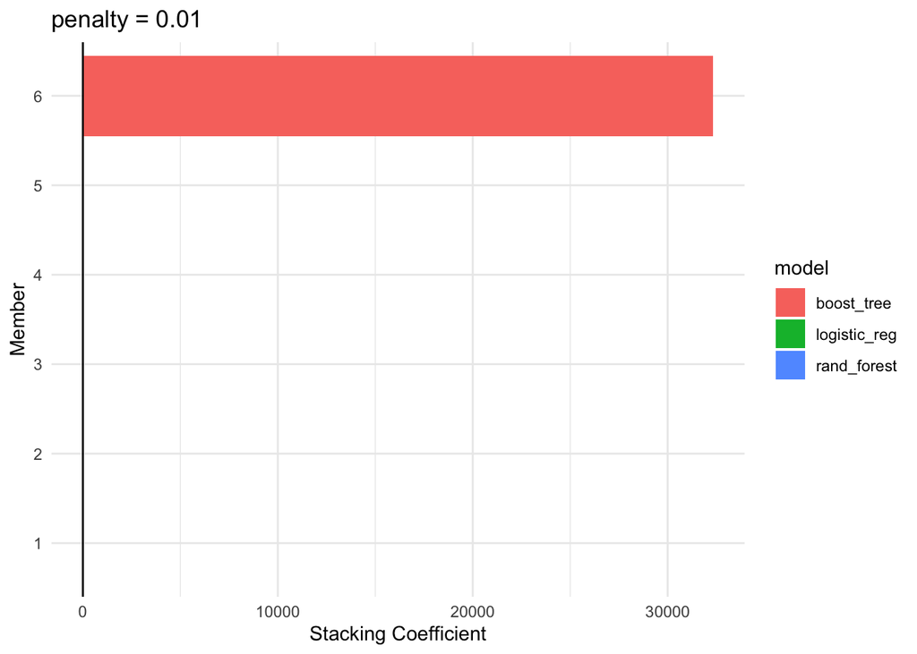

```r
set.seed(494)
lending_blend <-
  lending_stack %>%
  blend_predictions()

autoplot(lending_blend,type = "weights")
```

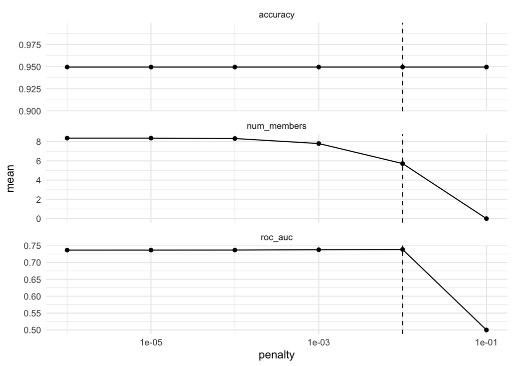

```r
autoplot(lending_blend)
```

> In my model, boosting is contributing the most. Also, from the plot, I think I captured the best one.
13. Fit the final stacked model using `fit_members()`. Apply the model to the training data. Compute the accuracy, construct a confusion matrix, and create a density plot with `.pred_good` on the x-axis (the probability of a response of “good”), filled by `Class`. Comment on what you see.

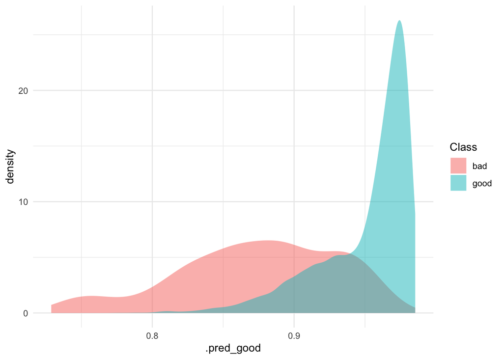

```r
lending_final_stack <-
  lending_blend %>%
  fit_members()

lending_final_stack %>%
  predict(new_data = lending_training,type = "prob") %>%
  bind_cols(lending_training) %>%
  ggplot(aes(x = .pred_good,fill = Class)) +
  geom_density(alpha = 0.5,
               color = NA)
```

```r
preds<- lending_final_stack %>%
  predict(new_data = lending_training) %>%
  mutate(actual = lending_training$Class)

conf_mat(data = preds,truth = actual,estimate = .pred_class)
```

```
##           Truth
## Prediction  bad good
##       bad     0    0
##       good  383 7009
```

```r
accuracy(data = preds,truth = actual,estimate = .pred_class)
```

| .metric | .estimator | .estimate |
| --- | --- | --- |
| accuracy | binary | 0.9481872 |

> I notice that the acuracy is very high but all the bad class are misclassified.
14. In the previous problem, you saw that although the accuracy was quite high, the true negative rate (aka sensitivity) was terrible. It’s common to see this when one of the classes has low representation. What we want to do now is investigate what happens in each of our models. Below I’ve provided code to investigate the lasso model (where `lasso_tune` is the name of my tuning step). Do similar things for the random forest and xgboost models. If you’d like to have a better true negative rate, which models would you choose and how would you go about doing this in a less manual way (you don’t need to write code to do it - just describe it in words). Be sure to remove the `eval=FALSE` when you are finished.

```r
lasso_tune %>%
  collect_predictions() %>%
  group_by(id, penalty) %>%
  summarize(accuracy = sum((Class == .pred_class))/n(),
            true_neg_rate = sum(Class == "bad" & .pred_class == "bad")/sum(Class == "bad"),
            true_pos_rate = sum(Class == "good" & .pred_class == "good")/sum(Class == "good")) %>%
  group_by(penalty) %>%
  summarize(across(accuracy:true_pos_rate, mean))
```

[output not shown]

```r
rf_tune %>%
  collect_predictions() %>%
  group_by(id, mtry,min_n) %>%
  summarize(accuracy = sum((Class == .pred_class))/n(),
            true_neg_rate = sum(Class == "bad" & .pred_class == "bad")/sum(Class == "bad"),
            true_pos_rate = sum(Class == "good" & .pred_class == "good")/sum(Class == "good")) %>%
  group_by(id, mtry,min_n) %>%
  summarize(across(accuracy:true_pos_rate, mean))
```

[output not shown]

```r
boost_tune %>%
  collect_predictions() %>%
  group_by(id, learn_rate) %>%
  summarize(accuracy = sum((Class == .pred_class))/n(),
            true_neg_rate = sum(Class == "bad" & .pred_class == "bad")/sum(Class == "bad"),
            true_pos_rate = sum(Class == "good" & .pred_class == "good")/sum(Class == "good")) %>%
  group_by(id, learn_rate) %>%
  summarize(across(accuracy:true_pos_rate, mean))
```

[output not shown]

> If I want to have a better true negative rate, I would chooce boosting or lasso model. Instead of doing it manualy, one thing I could do is to set bars for accuracy and true_neg_rate and filter out the models which have accuracy and true_neg_rate higher than the bars. Then, we could find means of accuracy and true_neg_rate for each model under different parameters and choose the model with higher accuracy.

## Shiny app

For this week, there is no code to turn in for this part. You are just going to need to think about the steps to take.

If you are new to Shiny apps or it’s been awhile since you’ve made one, visit the Shiny links on our course [Resource](https://advanced-ds-in-r.netlify.app/resources.html) page. I would recommend starting with my resource because it will be the most basic.

Everyone should watch the [Theming Shiny](https://youtu.be/b9WWNO4P2nY) talk by Carson Sievert so you can make your app look amazing.

**Tasks:**

In the future, you are going to create an app that allows a user to explore how the predicted probability of a loan being paid back (or maybe just the predicted class - either “good” or “bad”) changes depending on the values of the predictor variables.

For this week, I want you to answer the following questions:

1. How can you save a model you built to use it later (like in the shiny app you’ll create)?

> I can use save() function in R to save the model to local and then use it in the shiny app.
2. For shiny apps that get published (like yours will), it’s very important to have ALL the libraries that are used within the app loaded. If we were going to use the stacked model, which libraries do you think we’d need to load in our app?

library(tidyverse) # for graphing and data cleaning  
library(tidymodels) # for modeling  
library(doParallel) # for parallel processing  
library(stacks) # for stacking models  
library(lubridate) # for date manipulation  
library(vip) # for variable importance plots  
library(themis)

3. You’ll want the user to be able to choose values for each variable in the model. How will you come up with the values they can choose for quantitative and categorical data? Give one example for each, either using code or in words.

> For quantitative data, I can give them a range to choose from, for example the 50% data in the middle, probably using sliderInput(). For categorical data, I probably will give them options by using selectInput().
4. You will need to populate each variable with an initial value. Which value will you choose? Is there a nice way to do this programatically (ie. with code)?

> I will probably choose the mean of each quantitative variable and for categorical variable, I will see which classes are more dominant in the dataset.

```r
lending_club %>%
  select(where(is.numeric)) %>%
  pivot_longer(cols = everything(),
               names_to = "variable",
               values_to = "value") %>%
  group_by(variable) %>%
  summarise(avg = mean(value))
```

| variable | avg |
| --- | --- |
| acc_now_delinq | 6.289946e-03 |
| all_util | 6.030679e+01 |
| annual_inc | 8.032036e+04 |
| delinq_2yrs | 3.279903e-01 |
| delinq_amnt | 1.216790e+01 |
| funded_amnt | 1.568356e+04 |
| inq_fi | 9.347672e-01 |
| inq_last_12m | 2.185452e+00 |
| inq_last_6mths | 5.846606e-01 |
| int_rate | 1.252654e+01 |

[output cut: 7 more lines]

```r
lending_club %>%
  select(where(is.factor)) %>%
  pivot_longer(cols = everything(),
               names_to = "variable",
               values_to = "value") %>%
  group_by(variable,value) %>%
  count()
```

| variable | value | n |
| --- | --- | --- |
| addr_state | AK | 26 |
| addr_state | AL | 115 |
| addr_state | AR | 81 |
| addr_state | AZ | 223 |
| addr_state | CA | 1324 |
| addr_state | CO | 175 |
| addr_state | CT | 143 |
| addr_state | DC | 19 |
| addr_state | DE | 27 |
| addr_state | FL | 731 |

[output cut: 94 more lines]

## Function Friday problems

I will link to these separately. They will be posted by Tuesday.

## Coded Bias

We will be watching some of the [Coded Bias](https://www.codedbias.com/) film together on Thursday. It is streaming on Netflix. Write a short reflection. If you want some prompts, reflect on: What part of the film impacted you the most? Was there a part that surprised you and why? What emotions did you experience while watching?

> The part that the police use AI to detect potential criminals impacted me the most. Seeing an innocent 14-years-old boy being stopped by police makes me feel very sad and I’m surprised that people will be fined if they cover their faces, which is a decision supported by human rights. Watching this film makes me think about more ethical aspects of AI and I’m happy that the team in the film made some progress in the end!

REMEMBER TO ADD YOUR GITHUB LINK AT THE TOP OF THE PAGE AND UNCOMMENT THE `knitr` OPTIONS.